# DM_Assignment5_Duo_Zhou

Duo Zhou

8/22/2020

## Part 1

Use the GermanCredit data (package caret) in R Cluster-wise regression

Load in Anil’s clustreg and clustreg.predict functions;

```r
source('clustreg.R')
source('clustreg_predict.R')
```

Use the other 6 numeric variables as independent variables. If you use caret package data, this will be columns 1 and 3 through 7 (typo is assignment). Align your data frame for training and test so that amount in the first column and the following 6 are the other 6 numeric variables.

```r
data("GermanCredit")

#Select only numerical data
GermanCredit<- GermanCredit[c(2, 1,3:7)]

#Split train/test set
set.seed(12345)
train.inx<- sample(1:nrow(GermanCredit), 0.70 * nrow(GermanCredit))
test.inx<- setdiff(1:nrow(GermanCredit), train.inx)

Train.GC<- GermanCredit[train.inx,]
Test.GC<- GermanCredit[test.inx, ]
```

Perform clusters wise regression for 1, 2, and 3 clusters.

```r
GC.CR.1<- clustreg(Train.GC, 1, 1, 123, 1)
GC.CR.2<- clustreg(Train.GC, 2, 2, 123, 10)
GC.CR.3<- clustreg(Train.GC, 3, 2, 123, 10)
```

Explore the attributes and find the best R squared for each cluster solution. Plot this r squared as a function of number of clusters.

```r
names(GC.CR.1)
```

```
## [1] "data"         "nclust"       "tries"        "seed"         "rsq.best"
## [6] "number.loops" "Best.try"     "cluster"      "results"
```

```r
(rb.1<- GC.CR.1$rsq.best)
```

```
## [1] 0.5098078
```

```r
(rb.2<- GC.CR.2$rsq.best)
```

```
## [1] 0.8247437
```

```r
(rb.3<- GC.CR.3$rsq.best)
```

```
## [1] 0.8583275
```

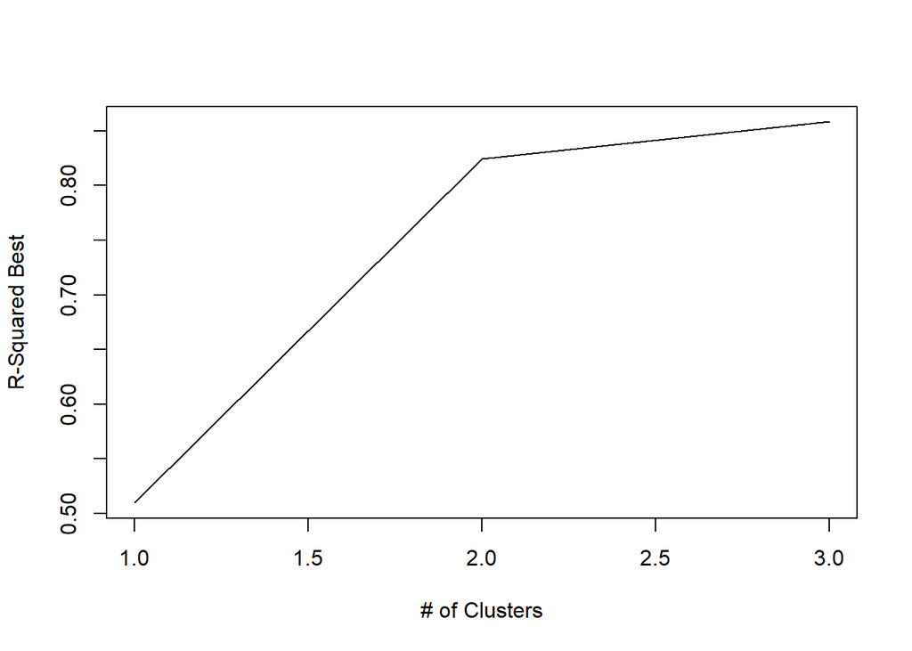

```r
plot(c(rb.1, rb.2, rb.3),
xlab = "# of Clusters", ylab = "R-Squared Best", type = "l")
```

Note that the elbow occurs when k=2.

Perform holdout on each of the 3 cluster models using the clustreg.predict function. Arguments are the appropriate train model and holdout data.

```r
Test.pred.1<- clustreg.predict(GC.CR.1, Test.GC)
Test.pred.2<- clustreg.predict(GC.CR.2, Test.GC)
Test.pred.3<- clustreg.predict(GC.CR.3, Test.GC)
```

Find the best r squared from each of the holdout models. Show a table of R squared from train, r squared from holdout, and percentage decrease from train to holdout R squared: (Train R square – Holdout R square)/ Train R square.

```r
(rb.test.1<- Test.pred.1$rsq)
```

```
## [1] 0.467277
```

```r
(rb.test.2<- Test.pred.2$rsq)
```

```
## [1] 0.7928091
```

```r
(rb.test.3<- Test.pred.3$rsq)
```

```
## [1] 0.8497248
```

```r
train.rsq<- c(rb.1,rb.2,rb.3)
test.rsq<- c(rb.test.1,rb.test.2,rb.test.3)
perc.dec<- (train.rsq-test.rsq)/train.rsq
table<-cbind('Train R^2'=train.rsq,'Test R^2'=test.rsq,
             'Percentage Decrease'=perc.dec)
rownames(table)<-c('Model 1', 'Model 2','Model 3')
as.table(table)
```

```
##          Train R^2   Test R^2 Percentage Decrease
## Model 1 0.50980780 0.46727703          0.08342512
## Model 2 0.82474369 0.79280909          0.03872063
## Model 3 0.85832749 0.84972478          0.01002264
```

Out of the three models, Model 3 with 3 clusters and 10 iterations, gives the best R2 in both train and test data results. Model 3 also gives the smallest R^2 decrease. Model 3 is definitely the best model.

## Part 2

Use the Diabetes Readmissions data (on Canvas) to perform Linear and Quadratic Discriminant Analysis

Using undummy dataset.

```r
dataPath <- "C:/Users/zd000/Desktop/MSCA/Data Mining/Assignments/week5/"
DB<- read.csv(paste(dataPath, "diabetes_preprocessed_nodummies.csv", sep = "/"), header = TRUE)
head(DB)
```

```
##              race gender age admission_type_id discharge_disposition_id
## 1       Caucasian      0   5                 5                       25
## 2       Caucasian      0  15                 1                        1
## 3 AfricanAmerican      0  25                 1                        1
## 4       Caucasian      1  35                 1                        1
## 5       Caucasian      1  45                 1                        1
## 6       Caucasian      1  55                 1                        1
##   time_in_hospital num_lab_procedures num_procedures num_medications
## 1                1                 41              0               1
## 2                3                 59              0              18
## 3                2                 11              5              13
## 4                2                 44              1              16
## 5                1                 51              0               8
## 6                3                 31              6              16
##   number_outpatient number_emergency number_inpatient      diag_1
```

[output cut: 41 more lines]

1. Select variables

```r
categorical_cols = c('gender','race','admission_type_id','discharge_disposition_id','change', 'diabetesMed', 'readmitted')

DB[, categorical_cols] <- lapply(DB[, categorical_cols],as.factor)
DB <- na.omit(DB)

sel_cols <- c( "time_in_hospital", "num_lab_procedures", "num_procedures", "num_medications","number_outpatient", "number_emergency","race", "gender" , "age", "number_inpatient","number_diagnoses", "max_glu_serum", "A1Cresult","readmitted", "admission_type_id", "metformin", "repaglinide", "nateglinide", "glimepiride" ,  "glipizide", "glyburide", "tolbutamide","pioglitazone", "rosiglitazone", "acarbose","troglitazone", "tolazamide", "insulin", "change", "diabetesMed" , "glyburide.metformin","glipizide.metformin")

DB <- DB[, sel_cols]
```

2. Split into train and test data sets

```r
set.seed(12345)

train.ind<- sample(1:nrow(DB), 0.70 * nrow(DB))
test.ind<- setdiff(1:nrow(DB), train.ind)

DB.train<- DB[train.ind,]
DB.test<- DB[test.ind, ]
```

3. Run LDA using select predictors and predict class results for train and holdout

```r
LDA.m<- lda(readmitted~., data=DB.train)
LDA.train.pred  <- predict(LDA.m)$class
LDA.test.pred <- predict(LDA.m, newdata = DB.test)$class
```

4. Run QDA using select predictors and predict class results for train and holdout

```r
QDA.m<- qda(readmitted~., data=DB.train)
QDA.train.pred  <- predict(QDA.m)$class
QDA.test.pred <- predict(QDA.m, newdata = DB.test)$class
```

5. How often in train and test do LDA and QDA make the same prediction?

```r
LQ.same<-c(sum(LDA.train.pred==QDA.train.pred),sum(LDA.test.pred==QDA.test.pred))
p.LQ.same<-LQ.same/c(length(LDA.train.pred),length(LDA.test.pred))
table2<-cbind('Number of times LDA=QDA'=LQ.same, "% LDA=QDA "=p.LQ.same)
rownames(table2)<-c('Train', "Test")
as.table(table2)
```

```
##       Number of times LDA=QDA   % LDA=QDA
## Train            4.440400e+04 8.869801e-01
## Test             1.901300e+04 8.861391e-01
```

For both train and test data sets, about 88% of the predictions produced same result between LDA and QDA.

6. Compare confusion matrix for Train and holdout for LDA results for validation. Do the same for QDA results.

LDA

```r
(cm.LDA.train<-confusionMatrix(data=LDA.train.pred,reference=DB.train$readmitted))
```

```
## Confusion Matrix and Statistics
##
##           Reference
## Prediction     0     1
##          0 27326 16122
##          1  2712  3902
##
##                Accuracy : 0.6238
##                  95% CI : (0.6195, 0.628)
##     No Information Rate : 0.6
##     P-Value [Acc > NIR] : < 2.2e-16
##
##                   Kappa : 0.1177
##
##  Mcnemar's Test P-Value : < 2.2e-16
##
##             Sensitivity : 0.9097
##             Specificity : 0.1949
##          Pos Pred Value : 0.6289
##          Neg Pred Value : 0.5900
##              Prevalence : 0.6000
##          Detection Rate : 0.5458
##    Detection Prevalence : 0.8679
##       Balanced Accuracy : 0.5523
##
##        'Positive' Class : 0
##
```

```r
(cm.LDA.test<-confusionMatrix(data=LDA.test.pred,reference=DB.test$readmitted))
```

```
## Confusion Matrix and Statistics
##
##           Reference
## Prediction     0     1
##          0 11809  6872
##          1  1138  1637
##
##                Accuracy : 0.6267
##                  95% CI : (0.6202, 0.6332)
##     No Information Rate : 0.6034
##     P-Value [Acc > NIR] : 1.463e-12
##
##                   Kappa : 0.1181
##
##  Mcnemar's Test P-Value : < 2.2e-16
##
##             Sensitivity : 0.9121
##             Specificity : 0.1924
##          Pos Pred Value : 0.6321
##          Neg Pred Value : 0.5899
##              Prevalence : 0.6034
##          Detection Rate : 0.5504
##    Detection Prevalence : 0.8707
##       Balanced Accuracy : 0.5522
##
##        'Positive' Class : 0
##
```

QDA

```r
(cm.QDA.train<-confusionMatrix(data=QDA.train.pred,reference=DB.train$readmitted))
```

```
## Confusion Matrix and Statistics
##
##           Reference
## Prediction     0     1
##          0 26283 15611
##          1  3755  4413
##
##                Accuracy : 0.6132
##                  95% CI : (0.6089, 0.6174)
##     No Information Rate : 0.6
##     P-Value [Acc > NIR] : 9.305e-10
##
##                   Kappa : 0.1058
##
##  Mcnemar's Test P-Value : < 2.2e-16
##
##             Sensitivity : 0.8750
##             Specificity : 0.2204
##          Pos Pred Value : 0.6274
##          Neg Pred Value : 0.5403
##              Prevalence : 0.6000
##          Detection Rate : 0.5250
##    Detection Prevalence : 0.8368
##       Balanced Accuracy : 0.5477
##
##        'Positive' Class : 0
##
```

```r
(cm.QDA.test<-confusionMatrix(data=QDA.test.pred,reference=DB.test$readmitted))
```

```
## Confusion Matrix and Statistics
##
##           Reference
## Prediction     0     1
##          0 11278  6696
##          1  1669  1813
##
##                Accuracy : 0.6101
##                  95% CI : (0.6036, 0.6167)
##     No Information Rate : 0.6034
##     P-Value [Acc > NIR] : 0.02253
##
##                   Kappa : 0.0936
##
##  Mcnemar's Test P-Value : < 2e-16
##
##             Sensitivity : 0.8711
##             Specificity : 0.2131
##          Pos Pred Value : 0.6275
##          Neg Pred Value : 0.5207
##              Prevalence : 0.6034
##          Detection Rate : 0.5256
##    Detection Prevalence : 0.8377
##       Balanced Accuracy : 0.5421
##
##        'Positive' Class : 0
##
```

Summary of TP, FP and Accuracy

```r
TP<-c(TP.LDA.train=as.numeric(cm.LDA.train$byClass[1]),
      TP.LDA.test=as.numeric(cm.LDA.test$byClass[1]),
      TP.QDA.train=as.numeric(cm.QDA.train$byClass[1]),
      TP.QDA.test=as.numeric(cm.QDA.test$byClass[1]))


FP<-c(FP.LDA.train=1-as.numeric(cm.LDA.train$byClass[2]),
      FP.LDA.test=1-as.numeric(cm.LDA.test$byClass[2]),
      FP.QDA.train=1-as.numeric(cm.QDA.train$byClass[2]),
      FP.QDA.test=1-as.numeric(cm.QDA.test$byClass[2]))



accuracy<-c(accu.LDA.train=as.numeric(cm.LDA.train$overall[1]),
      accu.LDA.test=as.numeric(cm.LDA.test$overall[1]),
      accu.QDA.train=as.numeric(cm.QDA.train$overall[1]),
      accu.QDA.test=as.numeric(cm.QDA.test$overall[1]))


table3<-cbind(TP,FP,accuracy)
rownames(table3)<-c('LDA.Train','LDA.Test','QDA.Train','QDA.Test')
as.table(table3)
```

```
##                  TP        FP  accuracy
## LDA.Train 0.9097144 0.8051338 0.6237865
## LDA.Test  0.9121032 0.8076155 0.6266779
## QDA.Train 0.8749917 0.7796145 0.6131597
## QDA.Test  0.8710898 0.7869315 0.6101324
```

According to the confusion matrix, LDA produced a slightly better accuracy than QDA on both train and test data. The accuracy is very similar to what we obtained from decision tree and logistic models in assignment 4. Same TP/FP problem presisted in LDA and QDA model. Although both LDA and QDA produced high TP(sensitivity) values, they also produced very high FP(1-Specificity). A closer examination is needed in predictor selection.